# GHT- commentaires

JcB

27/01/2017

La Région grand Est (RGE) est composée de 10 départements

[output not shown]

```
Checking rgeos availability: TRUE
```

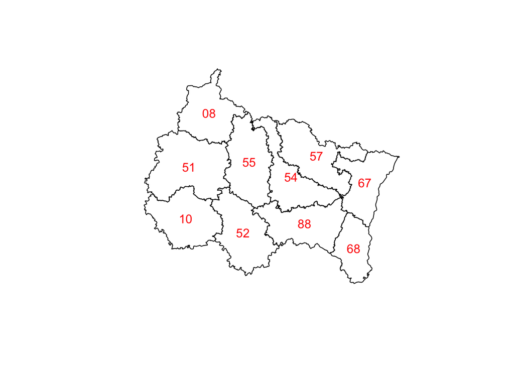

La région comporte 5200 communes:

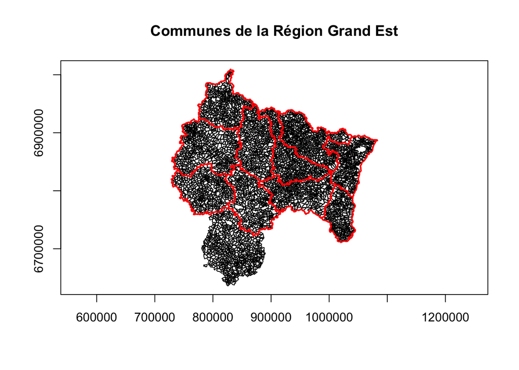

Les coordonnées sont indiquées en Lambert93 (conformes au JO)

La Région grand Est (RGE) est divisée en 12 groupements Hospitalier de territoire (GHT):

01 - GHT Nord Ardennes 02 - GHT Marne Sud Ardennes 03 - GHT de l’Aube et du Sézannais

04 - GHT 04 05 - GHT Marne Haute-Marne Meuse 06 - GHT Lorraine Nord

07 - GHT Sud Lorraine 08 - GHT Vosges 09 - GHT Moselle Est

10 - GHT 10 11 - GHT Centre Alsace 12 - GHT Haute Alsace

L’étude démographique utilise le fichier POP1B de l’INSEE qui donne par commune le nombre d’hommes et de femmes par trance de 1 an, de 0 à 100 ans et plus. Le fichier initial a été créé en 2013 puis mis à jour régulièrement. La dernière version date de juillet 2015.

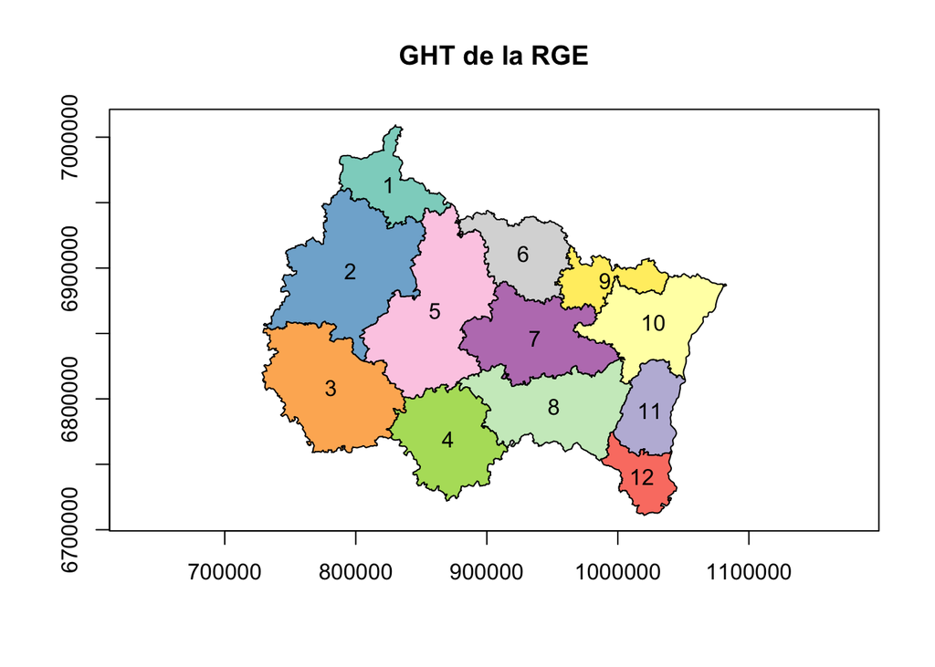

Plusieurs communes ont 0 habitant depuis la première Guerre mondiale.

# Etendue des GHT

```
##       surface (m2)       GHT
##  [1,] "2764323461.41728" "1"
##  [2,] "8148687429.20631" "2"
##  [3,] "7100805711.95334" "3"
##  [4,] "4860261233.2451"  "4"
##  [5,] "8411232269.96513" "5"
##  [6,] "3563420129.9844"  "6"
##  [7,] "5483992182.12344" "7"
##  [8,] "5891297313.82179" "8"
##  [9,] "2076550794.58396" "9"
## [10,] "4960296259.28506" "10"
## [11,] "2605379996.44195" "11"
## [12,] "1837472060.45918" "12"
```

```
##       surface (m2)       GHT
##  [1,] "1837472060.45918" "12"
##  [2,] "2076550794.58396" "9"
##  [3,] "2605379996.44195" "11"
##  [4,] "2764323461.41728" "1"
##  [5,] "3563420129.9844"  "6"
##  [6,] "4860261233.2451"  "4"
##  [7,] "4960296259.28506" "10"
##  [8,] "5483992182.12344" "7"
##  [9,] "5891297313.82179" "8"
## [10,] "7100805711.95334" "3"
## [11,] "8148687429.20631" "2"
## [12,] "8411232269.96513" "5"
```

Le GHT e plus petit est le n°12 (région de Mulhouse)

Le GHT le plus grand est le n°5

# Population

```
##      08      10      21      51      52      54      55      57      67
##  280907  306581  529761  569999  181521  731004  192094 1046873 1109460
##      68      71      88
##  758723   18511  375226
```

```
## [1] 6100660
```

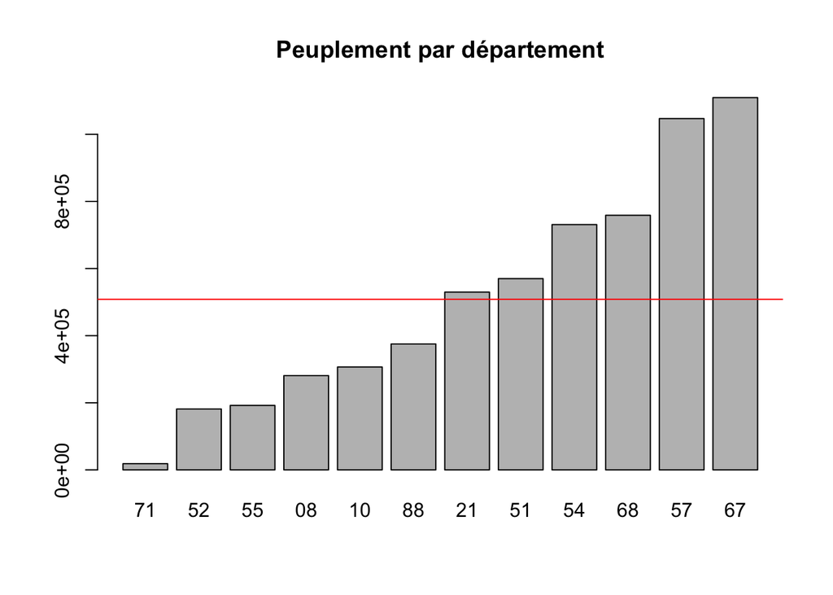

```
##       1       2       3       4       5       6       7       8       9
##  224185  551539  332951  662425  284520  801873  612150  375226  322407
##      10      11      12
## 1041847  408501  483036
```

```
## [1] 6100660
```

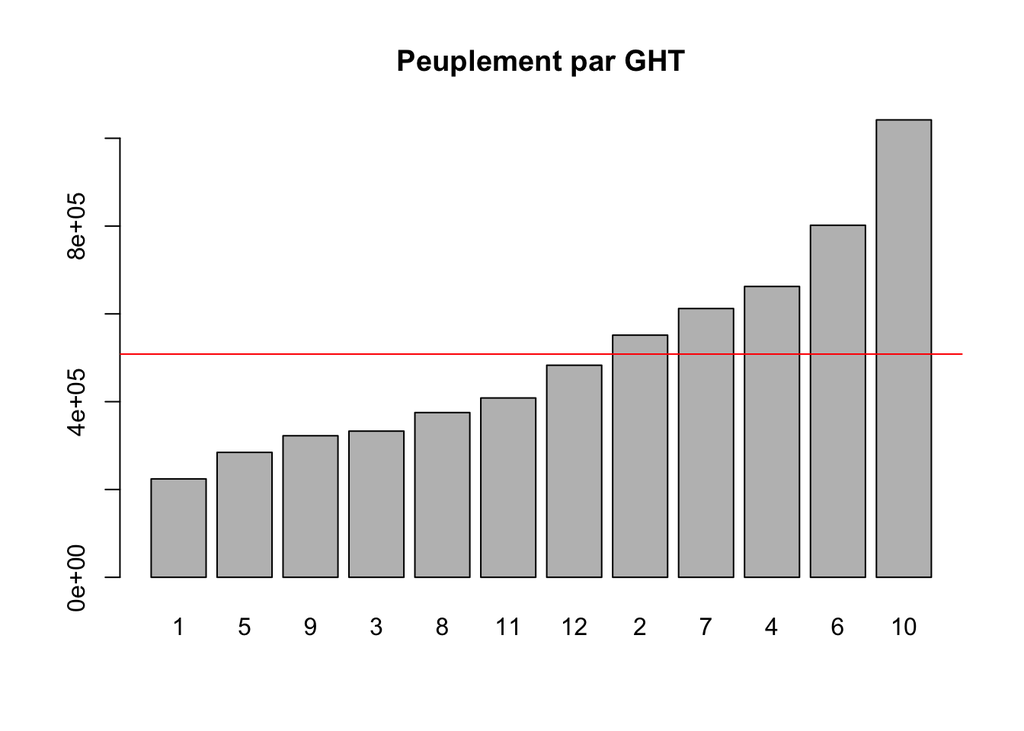